# Mini Project 1

Shivani, Sharan, Ajinkya, Anuhya

9/27/2021

## Data Preprocessing

Loading the data

```r
data2000 <- get_decennial(geography = "state",
                       variables = "P001001",
                       year = 2000)
```

```
## Using Census Summary File 1
```

```r
data2010 <- get_decennial(geography = "state",
                       variables = "P001001",
                       year = 2010)
```

```
## Using Census Summary File 1
```

```r
cpi = read_csv("Data/cpi.csv")
population = read_csv("Data/population.csv")
```

```r
SA = read_excel("Data/State_and_US_SA.xls",skip=5)
state_codes = read.table("Data/statecodes.txt",header=FALSE)
dens = get_estimates(geography = 'state', product = 'population', year = 2018)
dens = dens[dens$variable == "DENSITY" , ]
dens = dens[dens$NAME != "Puerto Rico", ]
#dens = dens[dens$NAME != "District of Columbia", ]

dens2 = get_estimates(geography = 'state', product = 'population', year = 2018)
dens2 = dens2[dens2$variable == "POP" , ]
dens2 = dens2[dens2$NAME != "Puerto Rico", ]
#dens2 = dens2[dens2$NAME != "District of Columbia", ]
```

```r
dates = data.frame(str_split_fixed(SA$Month,"M",n = 2))
SA$Month = dates$X2
SA$Year = dates$X1
SA = SA[,-c(53)]
new = melt(SA, id.vars = c("Month","Year"))
cpi_month = data.frame(str_split_fixed(cpi$Period,"M",n = 2))
cpi$Month = cpi_month$X2
cpi$Year = as.numeric(cpi$Year)
cpi$Month = as.numeric(cpi$Month)
new$Year = as.numeric(new$Year)
new$Month = as.numeric(new$Month)
new_dataset <- new %>% left_join(cpi , by=c("Year","Month"))
new_dataset = na.omit(new_dataset)
new_dataset = new_dataset %>% left_join(state_codes,by=c("variable" = "V2"))
```

Get the regions of all states in the US Function to assign regions according to the State Code

```r
NE.name <- c("Connecticut","Maine","Massachusetts","New Hampshire",
             "Rhode Island","Vermont","New Jersey","New York",
             "Pennsylvania")
NE.abrv <- c("CT","ME","MA","NH","RI","VT","NJ","NY","PA")
NE.ref <- c(NE.name,NE.abrv)

MW.name <- c("Indiana","Illinois","Michigan","Ohio","Wisconsin",
             "Iowa","Kansas","Minnesota","Missouri","Nebraska",
             "North Dakota","South Dakota")
MW.abrv <- c("IN","IL","MI","OH","WI","IA","KS","MN","MO","NE",
             "ND","SD")
MW.ref <- c(MW.name,MW.abrv)

S.name <- c("Delaware","District of Columbia","Florida","Georgia",
            "Maryland","North Carolina","South Carolina","Virginia",
            "West Virginia","Alabama","Kentucky","Mississippi",
            "Tennessee","Arkansas","Louisiana","Oklahoma","Texas")
S.abrv <- c("DE","DC","FL","GA","MD","NC","SC","VA","WV","AL",
            "KY","MS","TN","AR","LA","OK","TX")
S.ref <- c(S.name,S.abrv)

W.name <- c("Arizona","Colorado","Idaho","New Mexico","Montana",
            "Utah","Nevada","Wyoming","Alaska","California",
            "Hawaii","Oregon","Washington")
W.abrv <- c("AZ","CO","ID","NM","MT","UT","NV","WY","AK","CA",
            "HI","OR","WA")
W.ref <- c(W.name,W.abrv)

region.list <- list(
  Northeast=NE.ref,
  Midwest=MW.ref,
  South=S.ref,
  West=W.ref)
```

```r
new_dataset$regions <- sapply(new_dataset$variable,
                 function(x) names(region.list)[grep(x,region.list)])
```

Renaming the columns in the final Dataset.

```r
 new_dataset = new_dataset %>%
  rename(
   "State Code" = variable,
   "Index" = value,
   "CPI" = Value,
   "State" =  V3,
   "Regions" = regions)
```

Dropping unnecessary columns

```r
drops <- c("V1")
new_dataset = new_dataset[ , !(names(new_dataset) %in% drops)]
```

Adding the Price column to the Dataset

*CPI for the year December 2000 = 174.6

```r
new_dataset$Index = as.numeric(new_dataset$Index)
new_dataset$Price = (new_dataset$Index / new_dataset$CPI)*174.6
```

# Data Visualizations

## House prices over time

How have house prices in the U.S changed since 1975, after adjusting for inflation (i.e. relative to the CPI?)

Find year wise average of the Prices and plot the curve

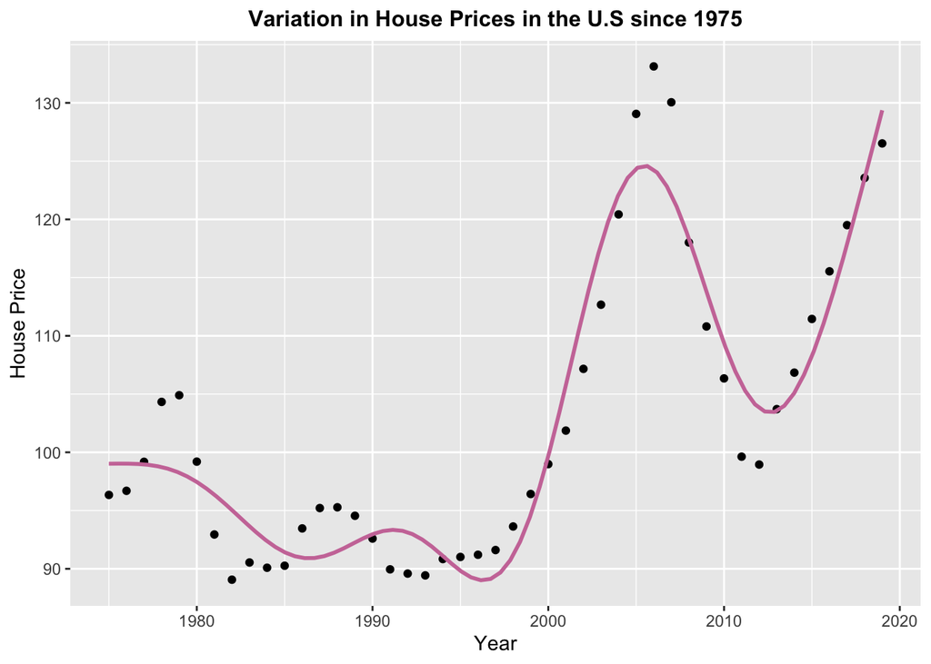

```r
year_wise_average = aggregate(Price ~ Year, FUN = mean, data = new_dataset)
ggplot(year_wise_average,aes(x=Year,y=Price))+
  geom_point()+
  geom_smooth(method="gam", formula = y~s(x), se = FALSE,color="#CC79A7")+  ylab('House Price')+
  ggtitle("Variation in House Prices in the U.S since 1975") + theme(plot.title = element_text(size = 12, face = "bold", hjust = 0.5))
```

### How have the prices varied by State?

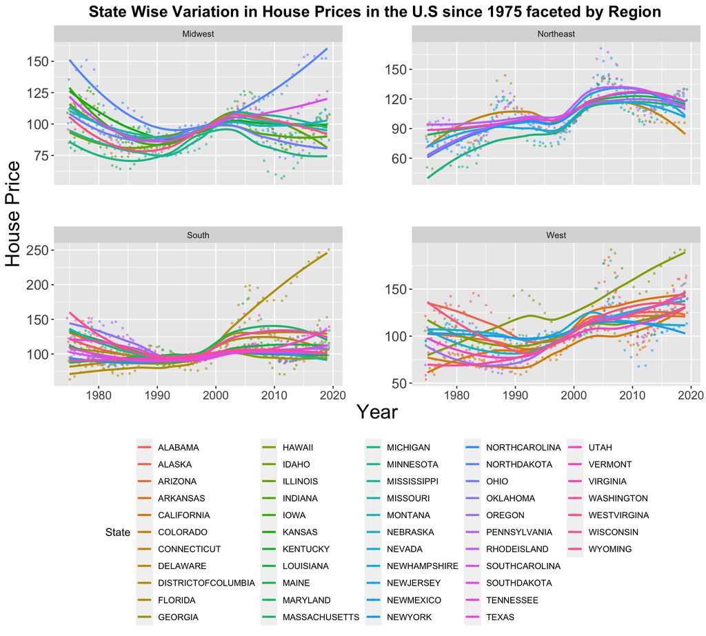

```r
library(gghighlight)
state_wise_year_average = aggregate(Price ~ Year + State + Regions , FUN = mean, data = new_dataset)
ggplot(state_wise_year_average,aes(x=Year,y=Price))+
  geom_jitter(aes(color=State),alpha=0.5,size=0.6)+ geom_smooth(aes(color=State),mehtod='lm',se=F)+
  facet_wrap(~Regions , nrow = 2,scales='free_y') + xlab("Year")+ ylab('House Price') +
  theme(panel.spacing = unit(1.5,"cm")) + theme(plot.title = element_text(size = 16, face = "bold", hjust = 0.5)) + ggtitle("State Wise Variation in House Prices in the U.S since 1975 faceted by Region ") + theme(axis.title=element_text(size=20),axis.text=element_text(size=14), legend.position = "bottom", axis.text.x=element_text(size=12))
```

- Which states have seen the biggest increases in real house prices, and which have seen the biggest decreases?
- Have changes in prices within each state mostly followed the same basic pattern,and are there outliers to that pattern?

### Do the typical patterns vary between the four regions (Northeast, Midwest, South, and West)?

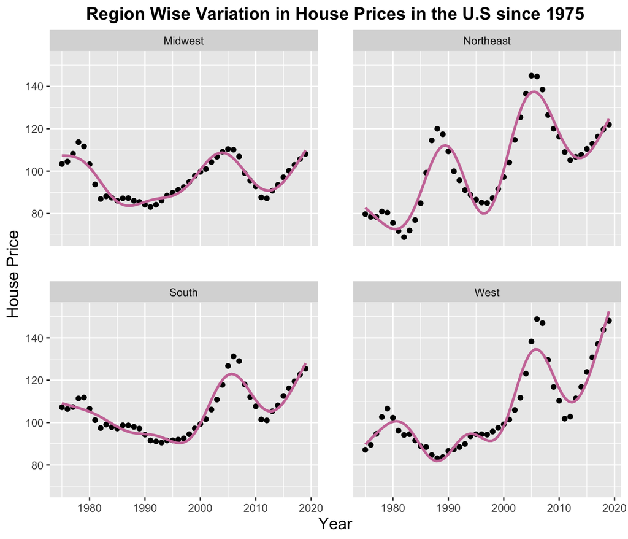

```r
region_wise_year_average = aggregate(Price ~ Year + Regions, FUN = mean, data = new_dataset)
ggplot(region_wise_year_average,aes(x=Year,y=Price))+
  geom_point()+ geom_smooth(method="gam", formula = y~s(x), se = FALSE,color="#CC79A7")+ facet_wrap(~ Regions, ncol =2) + ylab('House Price') + theme(panel.spacing = unit(1,"cm")) +  theme(plot.title = element_text(size = 14, face = "bold", hjust = 0.5)) +  theme(axis.title=element_text(size=13)) + labs(title = "Region Wise Variation in House Prices in the U.S since 1975")
```

## Population Density and change in house prices

### Does present-day population densityexplain changes in house prices by state since 1975?

```r
state_wise_1975 = state_wise_year_average[state_wise_year_average$Year=="1975",]
state_wise_2019 = state_wise_year_average[state_wise_year_average$Year=="2019",]
change_house_prices = (abs(state_wise_2019$Price - state_wise_1975$Price))/(state_wise_1975$Price)*100
```

dataframes for visualizing variation in house Price since 1975 w.r.t to population density

```r
dec18 = new_dataset[new_dataset$Month== 12 & new_dataset$Year== 2018,]
jan75 = new_dataset[new_dataset$Month== 1 & new_dataset$Year== 1975,]
change_house_prices = c(((dec18$Price - jan75$Price)/ jan75$Price)* 100)
state_abbrev_cut = state_codes[1:51,]
state_abbrev_cut = state_abbrev_cut[order(state_abbrev_cut$V3),]
state_wise_1975 = state_wise_1975[order(state_wise_1975$State),]
dens = dens[order(dens$NAME),]
population_price = data.frame(state_abbrev_cut$V2,state_wise_1975$State,change_house_prices,dens$value)
```

```r
nrow(dec18)
```

```
## [1] 51
```

Renaming the columns in Population

```r
names(population_price)[names(population_price) == 'state_wise_1975.State'] = 'State'
names(population_price)[names(population_price) == 'dens.value'] = 'Population_Density'
names(population_price)[names(population_price) == 'state_abbrev_cut.V2'] = 'Code'
```

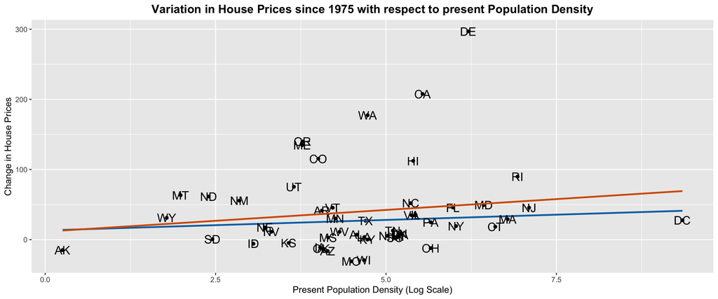

```r
ggplot(population_price,aes(x=log(Population_Density),y=change_house_prices))+geom_point()+ geom_smooth(method='rlm',color='#0072B2',se=FALSE) + theme(legend.position = "None") +  geom_text(aes(label = Code), size = 5) + geom_smooth(method='lm',color='#D55E00',se=FALSE) + ylab('Change in House Prices') + xlab('Present Population Density (Log Scale)') + ggtitle("Variation in House Prices since 1975 with respect to present Population Density") +  theme(plot.title = element_text(size = 14, face = "bold", hjust = 0.5))
```

```r
population_price_nodc = population_price[!population_price$State == 'DISTRICTOFCOLUMBIA',]
```

## With DC removed as an outlier

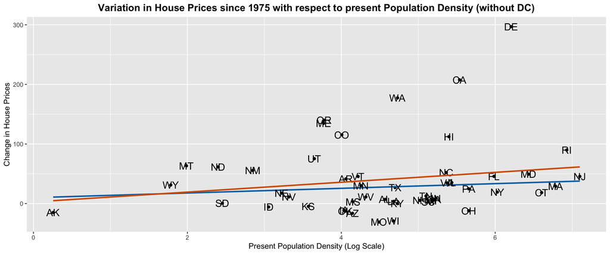

```r
ggplot(population_price_nodc,aes(x=log(Population_Density),y=change_house_prices))+geom_point()+ geom_smooth(method='rlm',color='#0072B2',se=FALSE) + theme(legend.position = "None") +  geom_text(aes(label = Code), size = 5) + geom_smooth(method='lm',color='#D55E00',se=FALSE) + ylab('Change in House Prices') + xlab('Present Population Density (Log Scale)') + ggtitle("Variation in House Prices since 1975 with respect to present Population Density (without DC)") +  theme(plot.title = element_text(size = 14, face = "bold", hjust = 0.5))
```

- Are there outliers to the relationship,and if so, is there a principled reason to drop them?
- What does the relationship look like after dropping or down weighting outliers?

### Does the relationship vary by region? If so, how?

```r
population_price_nodc$regions <- sapply(population_price_nodc$Code,
                 function(x) names(region.list)[grep(x,region.list)])
```

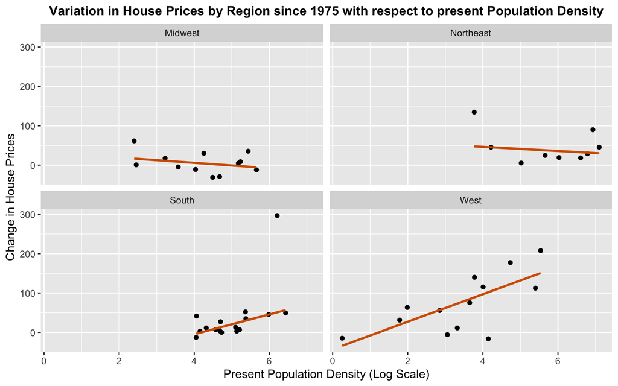

```r
ggplot(population_price_nodc,aes(x=log(Population_Density),y=change_house_prices))+geom_point()+ geom_smooth(method='rlm',color='#D55E00',se=FALSE) + theme(legend.position = "bottom") + facet_wrap(~regions) + ylab('Change in House Prices') + xlab('Present Population Density (Log Scale)') + ggtitle("Variation in House Prices by Region since 1975 with respect to present Population Density") +  theme(plot.title = element_text(size = 12, face = "bold", hjust = 0.5))
```

### Is there a relationship betweenchanges in population and changes in house prices? To answer this, look at changes in eachstate over three time periods: 1990 to 2000, 2000 to 2010, and 2010 to the present. Analyzethe three time periods separately.

### Has the relationship changed over the three time periods? Are there variations by region?

### 1990 to 2000 Population vs Price

```r
state_wise_1990 = state_wise_year_average[state_wise_year_average$Year=="1990",]
state_wise_2000 = state_wise_year_average[state_wise_year_average$Year=="2000",]
state_wise_1990 = state_wise_1990[order(state_wise_1990$State),]
state_wise_2000 = state_wise_2000[order(state_wise_2000$State),]
population  = population[order(population$`NHGIS Integrated State Name`),]
population = population[-c(52),]

change_pp1 = data_frame(matrix(NA,nrow=51,ncol=3))
change_pp1$State = state_wise_1990$State
change_pp1$Price = (state_wise_2000$Price - state_wise_1990$Price)/(state_wise_1990$Price)*100
change_pp1$Population = (population$`2000: Persons: Total` - population$`1990: Persons: Total`)/(population$`1990: Persons: Total`)*100
```

```r
change_pp1$Code = state_abbrev_cut$V2
change_pp1$Regions <- sapply(change_pp1$Code,
                 function(x) names(region.list)[grep(x,region.list)])
```

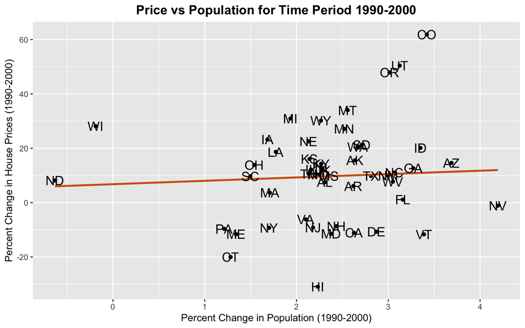

```r
ggplot(change_pp1,aes(x=log(Population),y=Price))+geom_point() +geom_smooth(method='rlm',color='#D55E00',se=FALSE) + geom_text(aes(label = Code), size = 5)  + ylab('Percent Change in House Prices (1990-2000)') + xlab('Percent Change in Population (1990-2000)') + ggtitle("Price vs Population for Time Period 1990-2000") +  theme(plot.title = element_text(size = 14, face = "bold", hjust = 0.5))
```

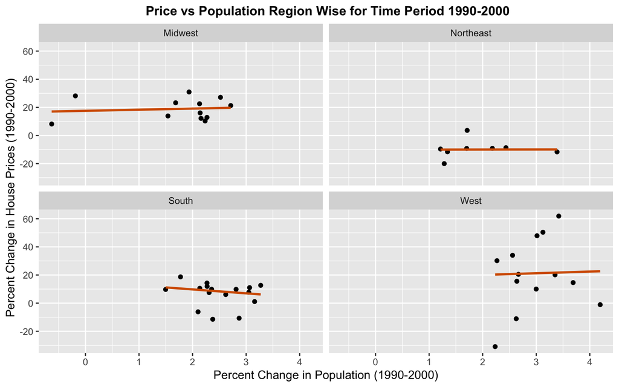

```r
ggplot(change_pp1,aes(x=log(Population),y=Price))+geom_point() +geom_smooth(method='rlm',color='#D55E00',se=FALSE) + facet_wrap(~Regions) + ylab('Percent Change in House Prices (1990-2000)') + xlab('Percent Change in Population (1990-2000)') + ggtitle(" Price vs Population Region Wise for Time Period 1990-2000") +  theme(plot.title = element_text(size = 12, face = "bold", hjust = 0.5))
```

### 2000 to 2010 Population vs Price

```r
state_wise_2010 = state_wise_year_average[state_wise_year_average$Year=="2010",]
state_wise_2010 = state_wise_2010[order(state_wise_2010$State),]
change_pp2 = data_frame(matrix(NA,nrow=51,ncol=3))
change_pp2$State = state_wise_2000$State
change_pp2$Price = (state_wise_2010$Price - state_wise_2000$Price)/(state_wise_2000$Price)*100
change_pp2$Population = (population$`2010: Persons: Total` - population$`2000: Persons: Total`)/(population$`2000: Persons: Total`)*100
```

```r
change_pp2$Code = state_abbrev_cut$V2
change_pp2$Regions <- sapply(change_pp2$Code,
                 function(x) names(region.list)[grep(x,region.list)])
```

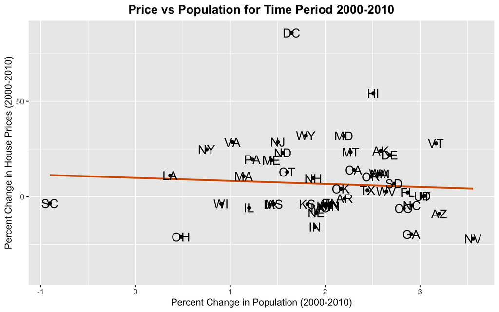

```r
ggplot(change_pp2,aes(x=log(Population),y=Price))+geom_point() +geom_smooth(method='rlm',color='#D55E00',se=FALSE) + geom_text(aes(label = Code), size = 5) + ylab('Percent Change in House Prices (2000-2010)') + xlab('Percent Change in Population (2000-2010)') + ggtitle("Price vs Population for Time Period 2000-2010") +  theme(plot.title = element_text(size = 14, face = "bold", hjust = 0.5))
```

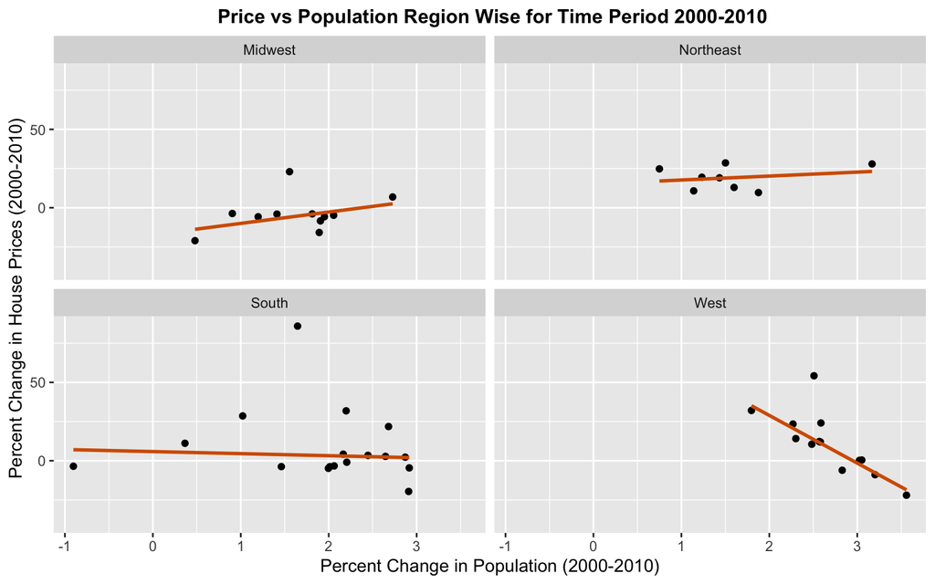

```r
ggplot(change_pp2,aes(x=log(Population),y=Price))+geom_point() +geom_smooth(method='rlm',color='#D55E00',se=FALSE) + facet_wrap(~Regions) + ylab('Percent Change in House Prices (2000-2010)') + xlab('Percent Change in Population (2000-2010)') + ggtitle(" Price vs Population Region Wise for Time Period 2000-2010") +  theme(plot.title = element_text(size = 12, face = "bold", hjust = 0.5))
```

### 2010 to present Population vs Price

```r
state_wise_2019 = state_wise_year_average[state_wise_year_average$Year=="2019",]
state_wise_2019 = state_wise_2019[order(state_wise_2019$State),]
change_pp3 = data_frame(matrix(NA,nrow=51,ncol=3))
change_pp3$State = state_wise_2010$State
change_pp3$Price = (state_wise_2019$Price - state_wise_2010$Price)/(state_wise_2010$Price)*100
dens2 = dens2[order(dens$NAME),]
change_pp3$Population = (dens2$value - population$`2010: Persons: Total`)/(population$`2010: Persons: Total`)*100
```

```r
change_pp3$Code = state_abbrev_cut$V2
change_pp3$Regions <- sapply(change_pp3$Code,
                 function(x) names(region.list)[grep(x,region.list)])
```

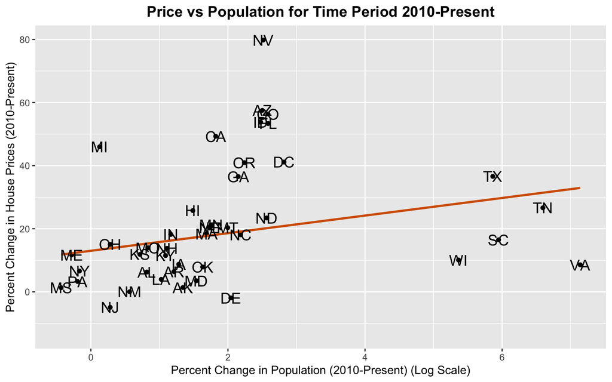

```r
ggplot(change_pp3,aes(x=log(Population),y=Price))+geom_point()  +geom_smooth(method='rlm',color='#D55E00',se=FALSE) + geom_text(aes(label = Code), size = 5) + ylab('Percent Change in House Prices (2010-Present)') + xlab('Percent Change in Population (2010-Present) (Log Scale)') + ggtitle("Price vs Population for Time Period 2010-Present") +  theme(plot.title = element_text(size = 14, face = "bold", hjust = 0.5))
```

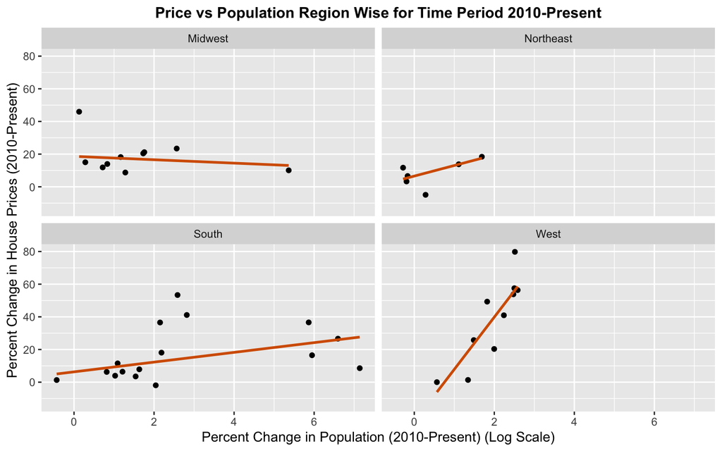

```r
ggplot(change_pp3,aes(x=log(Population),y=Price))+geom_point() +geom_smooth(method='rlm',color='#D55E00',se=FALSE) + facet_wrap(~Regions) + ylab('Percent Change in House Prices (2010-Present)') + xlab('Percent Change in Population (2010-Present) (Log Scale)') + ggtitle("Price vs Population Region Wise for Time Period 2010-Present") +  theme(plot.title = element_text(size = 12, face = "bold", hjust = 0.5))
```

### Population vs Price comparision of the three decades

creation of data frame for 3 decades comparison

```r
change_pp1$Year = '1990-2000'
change_pp2$Year = '2000-2010'
change_pp3$Year = '2010-Present'
```

```r
change_1 = rbind(change_pp1,change_pp2)
Change = rbind(change_1,change_pp3 )
```

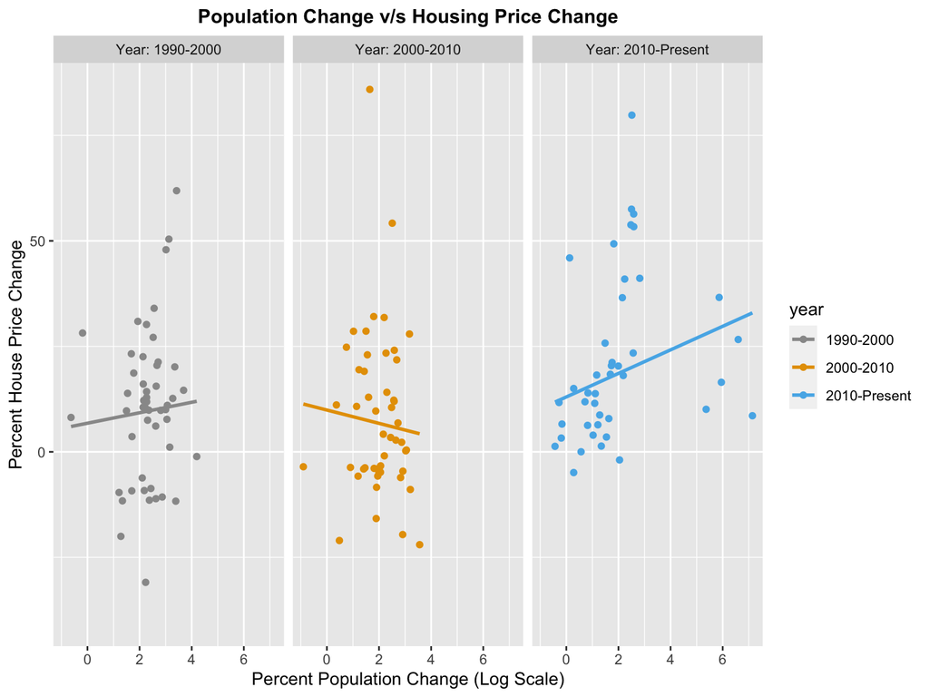

```r
ggplot(Change ,aes(x=log(Population),y=Price , group = Year, color = Year )) + geom_point() + geom_smooth(method='rlm',se=FALSE)+ facet_wrap(Year~. , labeller = "label_both") + scale_color_manual(values = cb_palette ) + labs(color ="year") +
ggtitle("Population Change v/s Housing Price Change") + ylab ("Percent House Price Change") + xlab("Percent Population Change (Log Scale)") + theme(plot.title = element_text(size = 12, face = "bold", hjust = 0.5))
```

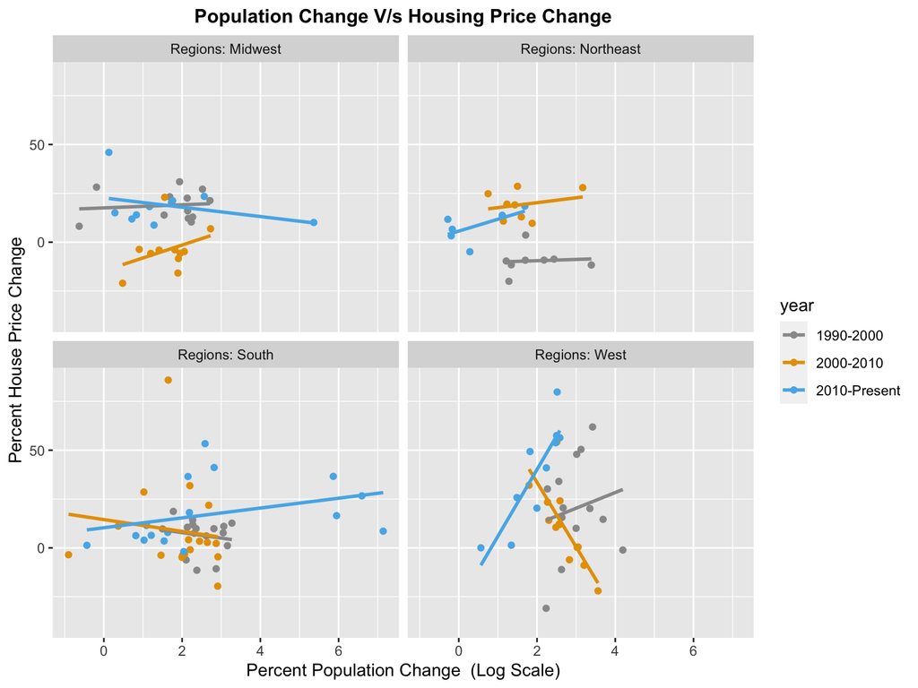

```r
ggplot(Change ,aes(x=log(Population),y=Price , group = Year, color = Year )) + geom_point() + geom_smooth(method='lm',se=FALSE)+ facet_wrap(Regions~. , labeller = "label_both") + scale_color_manual(values = cb_palette ) + labs(color ="year") +  ggtitle("Population Change V/s Housing Price Change") + ylab ("Percent House Price Change") + xlab("Percent Population Change  (Log Scale)") + theme(plot.title = element_text(size = 12, face = "bold", hjust = 0.5))
```